# Waimea Waves

Noah Salas

March 30, 2018

## Part 1

#### Framing the problem

- **Objective**: Hold WSL contest where, through the duration of the contest, the waves are at least 3 meters tall.
- **Strong’s Task**: Help WSL forecast wave heights at Waimea Bay so they can meet their objective.

Questions:

*Forecasts should be made at intersection of statistical confidence and business use*

- Length of contest? 1 day vs 3-4 days?
- Latest date a forecast is useful to you? 1 year, 6 months, 1 month?
- Such thing as too all of waves? (safety)
- Any reason to believe your current data has bias/measurement error?
- Seasonal/Business contraints? (travel/accommodation/tourism)
- Delivery of results and timing

#### Data Enrichment

- Additional wave height data ([Jason 3 satellite](https://www.nesdis.noaa.gov/jason-3/))
- Wind speed / direction - affects waves ([Wunderground](https://www.wunderground.com/personal-weather-station/dashboard?ID=KHIHALEI7#history))
- Precipitation - quality of competition and viewing ([Wunderground](https://www.wunderground.com/personal-weather-station/dashboard?ID=KHIHALEI7#history))
- Historical travel/accommodation use and costs

#### Data Integrity

```r
knitr::opts_chunk$set(cache=TRUE)
library(ggplot2)
library(reshape2)
library(lubridate)
library(dplyr)
library(forecast)
library(tseries)
X <- read.csv2("~/Documents/waimea_waves/wide.csv", header = TRUE, sep = ",", dec = ".", na.strings = "NA", stringsAsFactors = FALSE)
X$date <- as.Date(X$date)
```

Let’s first look at the wave heights of our 5 buoys:

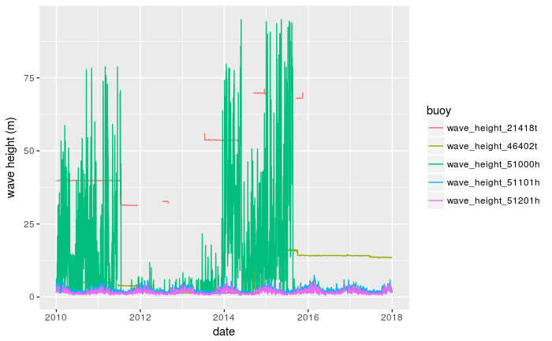

```r
Xp1 <- melt(X[,c("date","wave_height_21418t","wave_height_46402t","wave_height_51000h","wave_height_51101h","wave_height_51201h")],id="date")
colnames(Xp1) <- c("date","buoy","value")
ggplot(Xp1,aes(x=date,y=value,colour=buoy,group=buoy)) + geom_line() + ylab("wave height (m)")
```

Let’s check out the Japanese and Alaskan buoys with the Waimea Bay buoy.

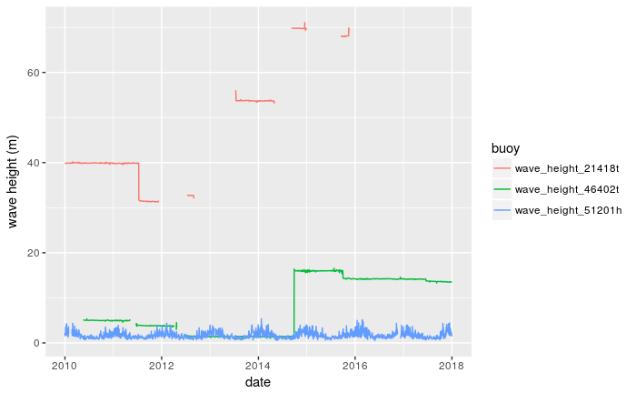

```r
Xp1 <- melt(X[,c("date","wave_height_21418t","wave_height_46402t","wave_height_51201h")],id="date")
colnames(Xp1) <- c("date","buoy","value")
ggplot(Xp1,aes(x=date,y=value,colour=buoy,group=buoy)) + geom_line() + ylab("wave height (m)")
```

Let’s set these features to the side for now.

N Hawaii 1 buoy wave height…

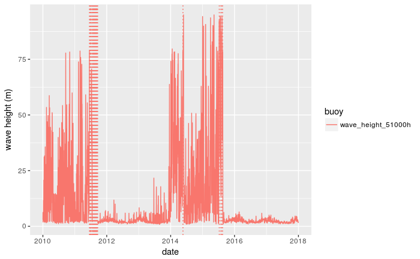

```r
Xp2 <- melt(X[,c("date","wave_height_51000h")],id="date")
colnames(Xp2) <- c("date","buoy","value")
ggplot(Xp2,aes(x=date,y=value,colour=buoy)) + geom_line() + ylab("wave height (m)") + geom_vline(xintercept=as.numeric(X$date[which(is.na(X[,c("wave_height_51000h")]))]), linetype="dotted", col="#F8766D")
```

So let’s focus on the NW Hawaii 2 and Waimea Bay buoys and their data

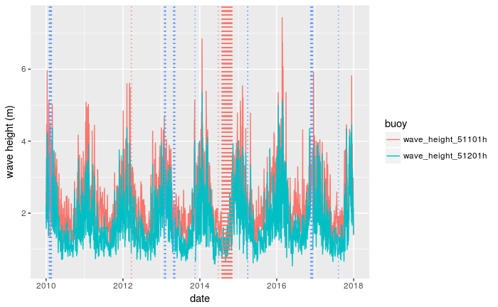

```r
Xp2 <- melt(X[,c("date","wave_height_51101h","wave_height_51201h")],id="date")
colnames(Xp2) <- c("date","buoy","value")
ggplot(Xp2,aes(x=date,y=value,colour=buoy)) + geom_line() + ylab("wave height (m)") + geom_vline(xintercept=as.numeric(X$date[which(is.na(X[,c("wave_height_51101h")]))]), linetype="dotted", col="#F8766D") + geom_vline(xintercept=as.numeric(X$date[which(is.na(X[,c("wave_height_51201h")]))]), linetype="dotted", col="#619CFF")
```

There doesn’t appear to be a missingness patern or overlap in missingness between the buoys. So if we wanted to impute these missing values, we could consider:

- The series’ own structure/autocorrelation
- Correlation with other features (buoys)
- Or both

#### Approaches

The data you’ve acquired for Strong to use is time related. Time related statistical analysis require certain considerations since a time series of wave height, for instance, is correlated with functions of itself.

Despite this, time series of interest ($y_t$) can sometimes be broken out into components. This can help us better understand them and forecast. These components are:

$$y_t = T_t + S_t + R_t$$

- **Trend** ($T_t$): *Long-term* increases or decreases in the data.
- **Seasonal** ($S_t$): A seasonal pattern in the data (yearly , monthly, etc.). This component is always fixed and has a known period.
- **Remainder** ($R_t$): Data variation that can’t be accounted for by the other components. Should be random.

Here is a visual example:

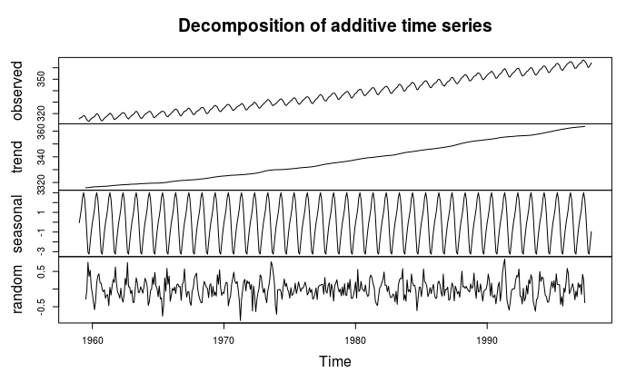

```r
plot(decompose(co2))
```

If we see something like this (which I suspect we will), it might be possible to get accurate forecasts with easy to understand methods such as moving averages or past (lagged) versions of our time series. So this is where I will start.

#### Communication

- Tailor to their needs- self-service vs evidence vs “tell me what to do”
- An application that key stakeholders could access regardless of time of year
  - Generate forecasts based off user defined time range
  - Confidence around forecasts (needs to be made very clear)
  - Other descriptive information layered on top (travel/accommodation costs and scheduling)

## Part 2

Modeling Process (Courtesy of Rob Hyndman):

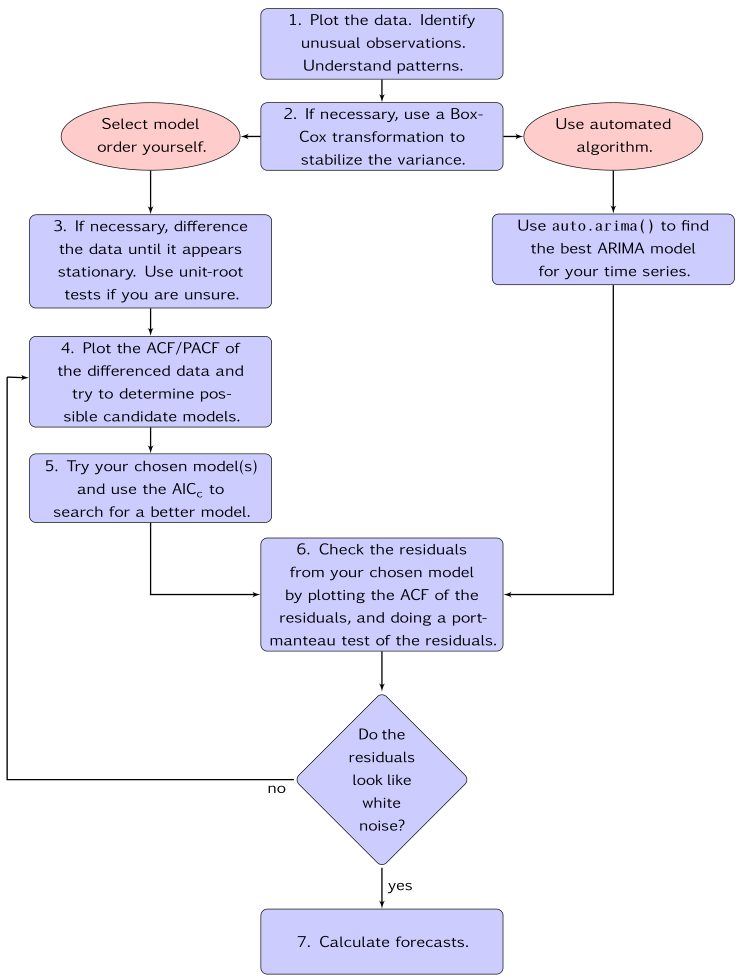

#### 1. EDA

Let’s look at some of our other features in comparison with the wave heights measured at Waimea Bay:

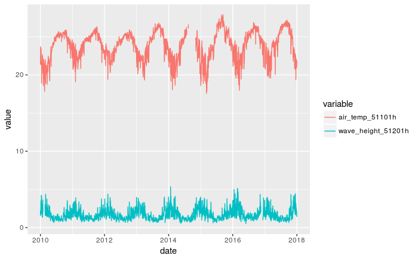

```r
Xp3 <- melt(X[,c("date","air_temp_51101h","wave_height_51201h")],id="date")
ggplot(Xp3,aes(x=date,y=value,colour=variable)) + geom_line()
```

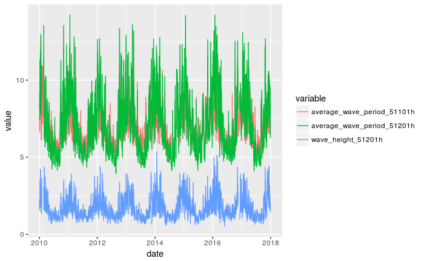

```r
Xp4 <- melt(X[,c("date","average_wave_period_51101h","average_wave_period_51201h","wave_height_51201h")],id="date")
ggplot(Xp4,aes(x=date,y=value,colour=variable)) + geom_line()
```

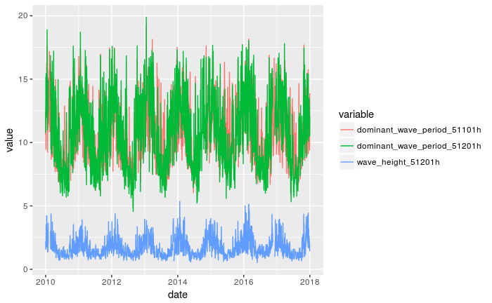

```r
Xp5 <- melt(X[,c("date","dominant_wave_period_51101h","dominant_wave_period_51201h","wave_height_51201h")],id="date")
ggplot(Xp5,aes(x=date,y=value,colour=variable)) + geom_line()
```

So it looks like most of these features (and their lags) are highly correlated with the Waimea Bay wave height (and its lags). So for now I’m going to move forward focusing on the wave height series to better understand and deconstruct it.

##### Missingness

As mentioned earlier we can handle missingness a few ways. I would think that we could use another series to inform us on what the missing Waimea Bay wave heights should be. For instance:

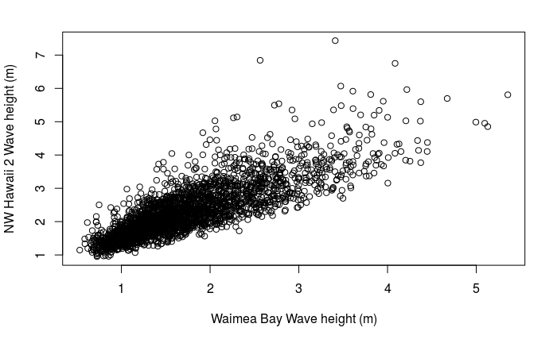

```r
plot(X$wave_height_51201h,X$wave_height_51101h, xlab = "Waimea Bay Wave height (m)", ylab = "NW Hawaii 2 Wave height (m)")
```

But then again maybe the series itself would be more informative on how to impute, like a simple linear interpolation. Let’s test this:

- I randomly select 1 of 2 sub-series of our NW Hawaii 2 and Waimea Bay wave height series where there’s no missing values.
- I randomly assign 25% of the samples in these sub-series to be holdout data, the rest I use to train with
- I run three methods on the training data:
  - Regress Waimea Bay wave height on NW Hawaii 2 wave height
  - Regress Waimea Bay wave height on NW Hawaii 2 wave height with AR(1) error term
  - Linearly interpolate Waimea Bay wave height
- Once I have these models, I evaluate them against the holdout set, and generate a RMSE
- Repeat $n$ times

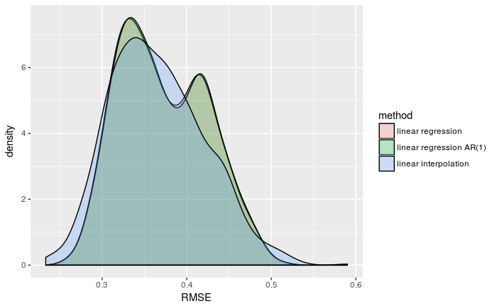

```r
#missingness
set.seed(1234)
train_prop = .75
n = 1000
m = c("linear regression", "linear regression AR(1)", "linear interpolation")
k = length(m)
miss_mat <- matrix(data=NA, nrow=n, ncol=k)
for(i in 1:n){

  if(runif(1) >= 0.5){
    Xmiss <- X[X$date >= "2010-03-01" & X$date <= "2012-01-01",]
  } else {
    Xmiss <- X[X$date >= "2015-05-01" & X$date <= "2016-11-01",]
  }

  train <- sample.int(n = nrow(Xmiss), size = floor(train_prop*nrow(Xmiss)), replace = FALSE)
  ys <- Xmiss$wave_height_51201h[-train]

  miss_mod_lm <- arima(Xmiss$wave_height_51201h[train], order = c(0,0,0) , xreg=Xmiss$wave_height_51101h[train])
  preds <- predict(miss_mod_lm, newxreg= Xmiss$wave_height_51101h[-train])$pred

  miss_mod_ar <- arima(Xmiss$wave_height_51201h[train], order = c(1,0,0) , xreg=Xmiss$wave_height_51101h[train])
  preds2 <- predict(miss_mod_ar , newxreg= Xmiss$wave_height_51101h[-train])$pred

  Xmiss$wave_height_51201h[-train] <- NA
  preds3 <- zoo::na.approx(Xmiss$wave_height_51201h, rule = 2)[-train]
  miss_mat[i,] <- c(sqrt(mean((preds - ys)^2)),
                    sqrt(mean((preds2 - ys)^2)),
                    sqrt(mean((preds3 - ys)^2)))
}
colnames(miss_mat) <- m
miss_plt <- melt(miss_mat[,1:3])[,2:3]
colnames(miss_plt) <- c("method","RMSE")
ggplot(miss_plt, aes(RMSE, fill = method)) + geom_density(alpha = 0.25)
```

It appears the three methods perform similarly on how well they impute missing values, so to keep things simple I will impute my Waimea Bay wave hieghts using linear interpolation

**Decisions**

1. Use Waimea Bay wave height as target (dependent) variable.
2. Keep data at daily level
3. Missingness handled by using linear interpolation imputation

#### 2. Variance

If we look more closely, at the Waimea Bay wave height series, it looks like the variance is not constant across the series (more spread at the spikes). Let’s investigate:

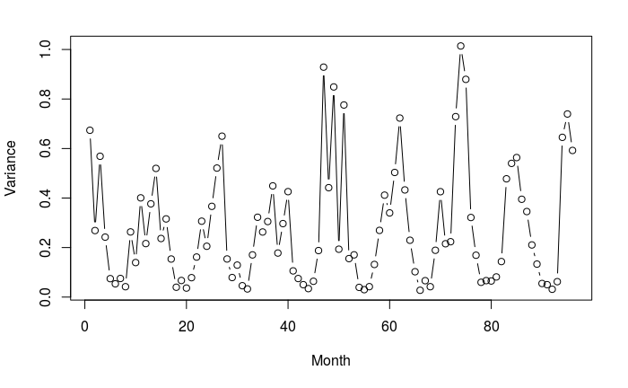

```r
wave_height_wb <- ts(zoo::na.approx(X$wave_height_51201h),start = c(2010,1),frequency = 365)
month_var <- X %>% group_by(year(X$date),month(X$date)) %>% summarise(variance = var(wave_height_51201h, na.rm = TRUE))
month_var$time <- 1:dim(month_var)[1]
plot(month_var$time,month_var$variance,type="b", xlab = "Month", ylab = "Variance")
```

This is an issue, the series needs to have constant variance over time so any model results are interpretable. We can use a Box-Cox transformation to help achieve this:

$$w_t = \frac{y_t^{\lambda} - 1}{\lambda}$$

We choose a lambda that will minimize the variation in this seasonal series:

```r
l <- BoxCox.lambda(wave_height_wb)
wave_height_wb_bc <- BoxCox(wave_height_wb,l)
print(l)
```

```
[1] -0.7583262
```

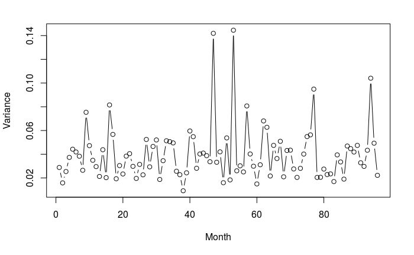

```r
month_var <- X %>% group_by(year(X$date),month(X$date)) %>% summarise(variance = var(BoxCox(wave_height_51201h,l), na.rm = TRUE))
month_var$time <- 1:dim(month_var)[1]
plot(month_var$time,month_var$variance, type="b", xlab = "Month", ylab = "Variance")
```

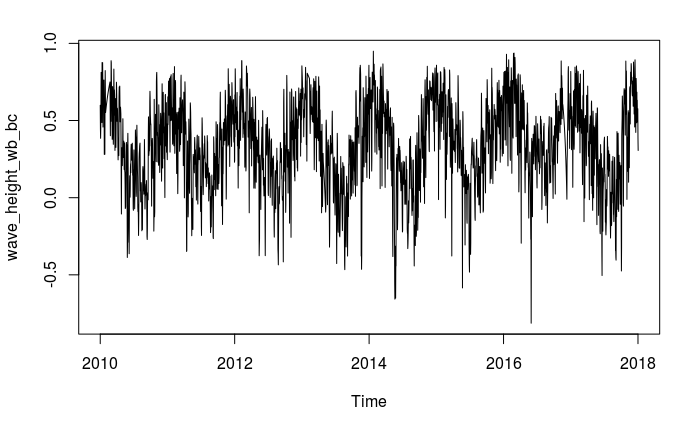

```r
plot(wave_height_wb_bc)
```

This transformed series now has a more constant variance.

**Decisions**

4. Use Box-Cox transformation to make variance more constant

#### 3. Stationarity

So let’s decompose our transformed series to see what we find. We will do this by first determining the trend component using a moving average. We remove it, then compute the seasonal component by averaging, for each time unit, over all periods. We then remove the seasonal component and the remainder is what’s left.

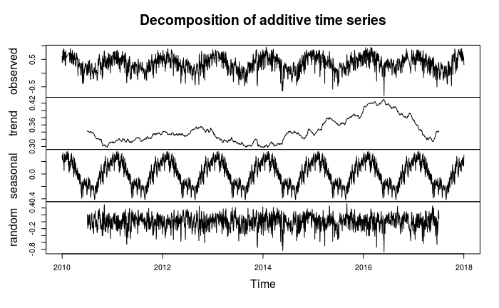

```r
d2 <- decompose(wave_height_wb_bc, type = "additive")
plot(decompose(wave_height_wb_bc))
```

As expected, more evidence of a yearly seasonal component. The trend component contributes very little to the overall series variablity:

```r
rbind(c("trend","seasonal","random"),
      c(var(d2$trend,na.rm = TRUE),var(d2$seasonal,na.rm = TRUE),var(d2$random,na.rm = TRUE)) / var(d2$x))
```

```
     [,1]                 [,2]                [,3]
[1,] "trend"              "seasonal"          "random"
[2,] "0.0145321495537638" "0.487267295705825" "0.468336627918005"
```

To finish making this series stationary, we need take this seasonal component into account. We can do this by differencing.

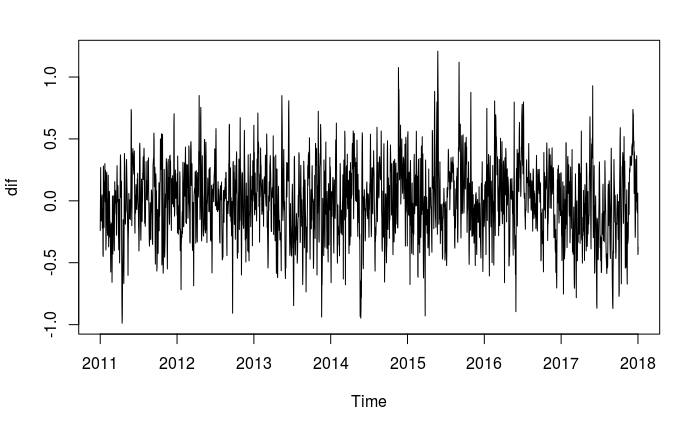

```r
dif <- diff(wave_height_wb_bc,365)
plot(dif)
```

**Decisions**

5. Use seasonal differencing

#### 4. ACF and PACF plots

*Autocorrelation function* (ACF) plots the coefficients of correlation between a time series and lags of itself. The *partial autocorrelation function* (PACF) plots the partial coefficients of correlation between a time series and lags of itself. Partial autocorrelation is the amount of correlation between a variable and a lag of itself that is not explained by correlations at all lower order lags.

Why do we care? These measures can help us identify the numbers of AR and/or MA terms that would be relevant to use in modeling

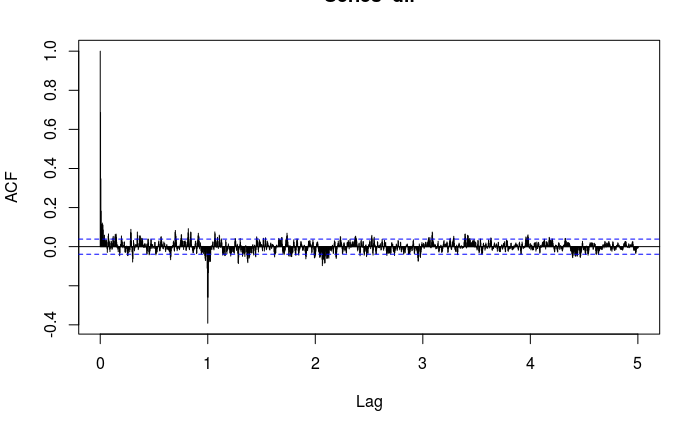

```r
acf(dif, lag.max = 365.25*5)
```

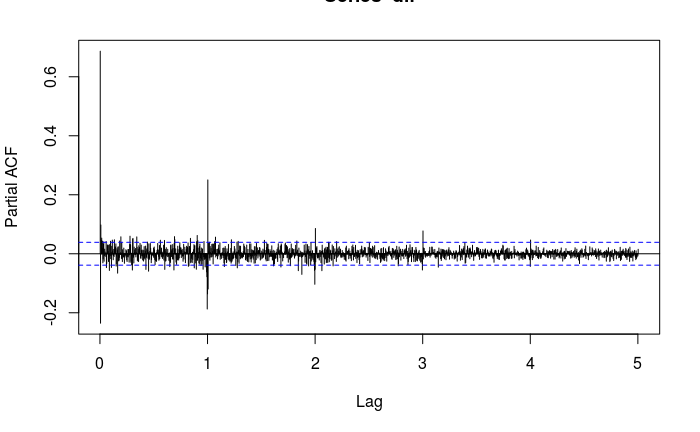

```r
pacf(dif, lag.max = 365.25*5)
```

The spikes and then tapering off of the spikes seasonally (just after each integer label) indicate a non-seasonal AR(1) and MA(1) term might be useful in the model.

**Decisions**

6. AR(1) and MA(1) terms seem useful to initiallizing modeling process

#### 5. Modeling

So the first model I’ll fit looks like this:

$$w_t^{'} = \phi_1 w_{t-1}^{'} + \theta_1 e_{t-1} + e_t$$
, where $w_t^{'}$ is the transformed and seasonally differenced Waimea Bay wave height time series.

```r
fit1 <- Arima(wave_height_wb,
      order = c(1,0,1),
      seasonal = c(0,1,0),
      lambda = l)
fit1
```

```
Series: wave_height_wb
ARIMA(1,0,1)(0,1,0)[365]
Box Cox transformation: lambda= -0.7583262

Coefficients:
         ar1     ma1
      0.5075  0.3639
s.e.  0.0230  0.0246

sigma^2 estimated as 0.0426:  log likelihood=407.13
AIC=-808.26   AICc=-808.25   BIC=-790.72
```

```r
tsdisplay(resid(fit1))
hist(resid(fit1),breaks=20)
```

[output not shown]

Let’s forecast a year out:

```r
f1 <- forecast(fit1,h=365)
plot(f1)
lines(f1$lower[,2], col="blue", lty="dashed")
```

[figure not shown]

```r
lines(f1$upper[,2], col="blue", lty="dashed")
```

While these forecasts seem logical, they are not seasonally smooth and vary considerably. This is because of the seasonal (365 day) differencing.

$K$ controls how many Fourier terms there are and can be tuned. The larger the $K$, the more ‘wiggly’ the seasonal pattern can become.

```r
fit_fourier_aicc <- vector()
for(i in 1:16){
  fittemp <- Arima(wave_height_wb, order=c(1,0,1), xreg=fourier(wave_height_wb, K=i), lambda=l)
  fit_fourier_aicc[i] <- fittemp$aicc
}
which.min(fit_fourier_aicc)
```

```
[1] 4
```

So let’s use this $K$:

```r
fitf <- Arima(wave_height_wb, order=c(1,0,1), xreg=fourier(wave_height_wb, K=which.min(fit_fourier_aicc)), lambda=l)
fitf
```

```
Series: wave_height_wb
Regression with ARIMA(1,0,1) errors
Box Cox transformation: lambda= -0.7583262

Coefficients:
         ar1     ma1  intercept  S1-365  C1-365   S2-365  C2-365   S3-365   C3-365  S4-365  C4-365
      0.4948  0.3855     0.3458  0.0929  0.2424  -0.0009  0.0028  -0.0121  -0.0386  0.0236  0.0235
s.e.  0.0216  0.0227     0.0074  0.0104  0.0104   0.0104  0.0104   0.0104   0.0104  0.0104  0.0104

sigma^2 estimated as 0.02125:  log likelihood=1485.84
AIC=-2947.68   AICc=-2947.57   BIC=-2875.92
```

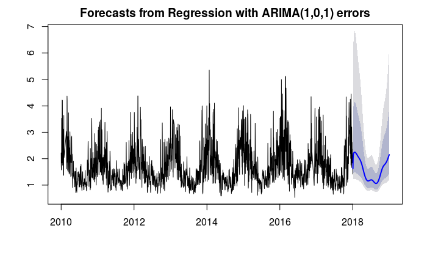

```r
ff <- forecast(fitf, h=365, xreg=fourier(wave_height_wb, K=which.min(fit_fourier_aicc), h=365))
plot(ff)
```

That looks better, let’s check the residuals:

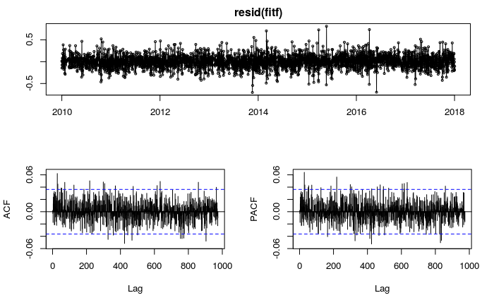

```r
tsdisplay(resid(fitf))
```

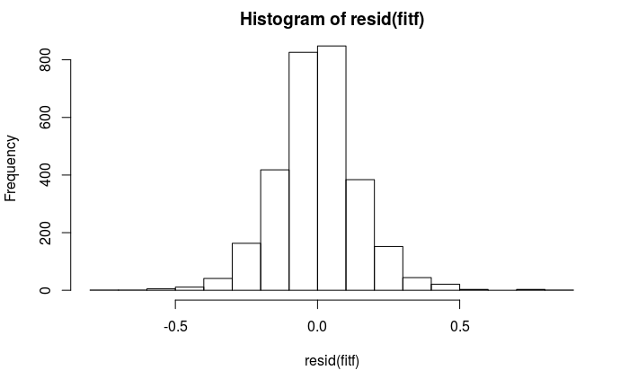

```r
hist(resid(fitf), breaks = 20)
```

Boom white noise.

##### Cross Validation

Before we move onto forecasting, let’s pressure test this model a bit more. We can do this using a time series style cross validation- take different ordinal slices of training and test data and generate an accuracy measure on each test set. It look like this (5 folds, black is training data, red is test data):

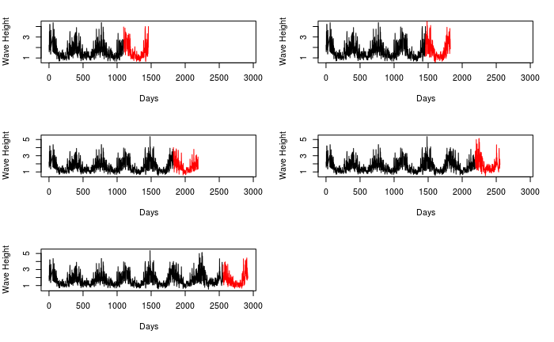

```r
par(mfrow = c(3,2))
k <- round(length(wave_height_wb)/365) - 3
base <- 365*2
a1 <- c(NA,NA,NA,NA,NA)
aa <- c(NA,NA,NA,NA,NA)
for(i in 1:k){
  train_end <- base + (i*365)
  test_start <- train_end + 1
  test_end <- test_start + 364

  train <- wave_height_wb[1:train_end]
  test <- wave_height_wb[test_start:test_end]

  plot(train, xlim = c(1,length(wave_height_wb)), type="l" , ylab = "Wave Height", xlab = "Days")
  lines(test_start:test_end,test,col="red")

}
```

Let’s compare my model to a basline of `auto.arima()` which attempts to automate model steps 3-5. The hope is my model’s cross validation error is less than those of a plug-n-play option:

```r
k <- round(length(wave_height_wb)/365) - 3
base <- 365*2
my_acc <- c(NA,NA,NA,NA,NA)
auto_acc <- c(NA,NA,NA,NA,NA)
for(i in 1:k){
  train_end <- base + (i*365)
  test_start <- train_end + 1
  test_end <- test_start + 364

  train <- ts(wave_height_wb[1:train_end],frequency = 365)
  test <- wave_height_wb[test_start:test_end]

  moda <- auto.arima(train,lambda = l)
  predsa <- forecast(moda,h=365)$mean
  a <- accuracy(f=predsa,x=test)
  auto_acc <- rbind(auto_acc,a)

  mod1 <- Arima(train, order=c(1,0,1), xreg=fourier(train, K=which.min(fit_fourier_aicc)), lambda=l)
  preds1 <- forecast(mod1, h=365, xreg=fourier(train, K=which.min(fit_fourier_aicc), h=365))$mean
  a <- accuracy(f=preds1,x=test)
  my_acc <- rbind(my_acc,a)

  #plot(forecast(mod1,h=365))
  #plot(forecast(moda, h=365, xreg=fourier(train, K=which.min(fit_fourier_aicc), h=365)))

}
#my_acc[-1,]
apply(my_acc[-1,], 2, mean)
```

```
        ME       RMSE        MAE        MPE       MAPE
 0.1918920  0.6179191  0.4365264  1.7360257 23.8320599
```

```r
#auto_acc[-1,]
apply(auto_acc[-1,], 2, mean)
```

```
        ME       RMSE        MAE        MPE       MAPE
 0.1503792  0.7364529  0.5447455 -6.7908518 32.2489604
```

My model appears to be performing better

**Decisions**

7. I settled on a model with Fourier transforms to handle seasonal dynamics and AR(1) / MA(1) errors to handle short term dynamics.
8. I validated this approach using a 5-fold cross validation.

#### 7. Forecasting

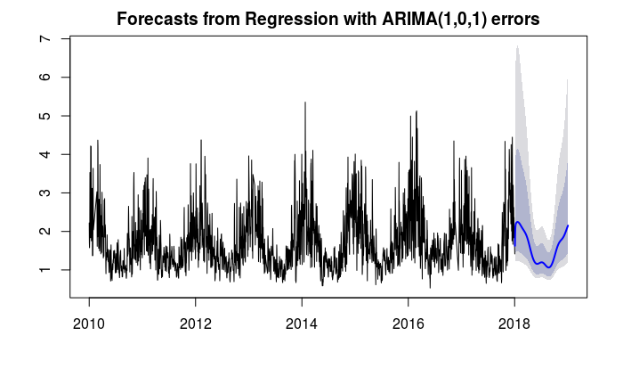

```r
ff <- forecast(fitf, h=365, xreg=fourier(wave_height_wb, K=which.min(fit_fourier_aicc), h=365))
plot(ff)
```

We can see that the forecast intervals get wider near the peaks, which we would expect.

Let’s check out the ten days in 2018 with the largest predicted Waimea Bay wave heights:

```r
fdf <- data.frame(date=tail(X$date,1)+1:365,
                  lower_80=ff$lower[,2],
                  est= ff$mean,
                  upper_80=ff$upper[,2])
head(fdf[order(fdf$est , decreasing = TRUE),],10)
```

|  | date | lower_80 | est | upper_80 |
| --- | --- | --- | --- | --- |
| 19 | 2018-01-19 | 1.239122 | 2.245285 | 6.823048 |
| 20 | 2018-01-20 | 1.239031 | 2.245027 | 6.821230 |
| 18 | 2018-01-18 | 1.239027 | 2.245014 | 6.821139 |
| 21 | 2018-01-21 | 1.238760 | 2.244255 | 6.815783 |
| 17 | 2018-01-17 | 1.238742 | 2.244204 | 6.815424 |
| 22 | 2018-01-22 | 1.238313 | 2.242984 | 6.806823 |
| 16 | 2018-01-16 | 1.238263 | 2.242844 | 6.805840 |
| 23 | 2018-01-23 | 1.237696 | 2.241230 | 6.794486 |
| 15 | 2018-01-15 | 1.237587 | 2.240923 | 6.792329 |
| 24 | 2018-01-24 | 1.236915 | 2.239014 | 6.778925 |

Not surprising that they are all next to each other in January.

#### Next Steps

I’ve been keeping track of important decisions I’ve made on this short modeling path, with the view of using alternatives of these as potential next steps / exploration. Let’s update this list a bit and describe some things I would investigate:

- Investigate the use of other features, both the ones already provided and new ones (particularly wind data)
  - Sensitivity around other buoys as part of target signal
  - Incorporate other covariates
- More thorough valuation of missing data imputation
- Investigate possibility / effectiveness of more than 1 seasonal pattern
- Model using other methods:
  - Exponential smoothing
  - Neural nets
  - Stack them?
- More extensive cross-validation routine
- Incorporate model and forecasts into easy to consume GUI / API